# Airbnb Geospatial Analysis: Best Areas for Investment

### Correlation HeatMap

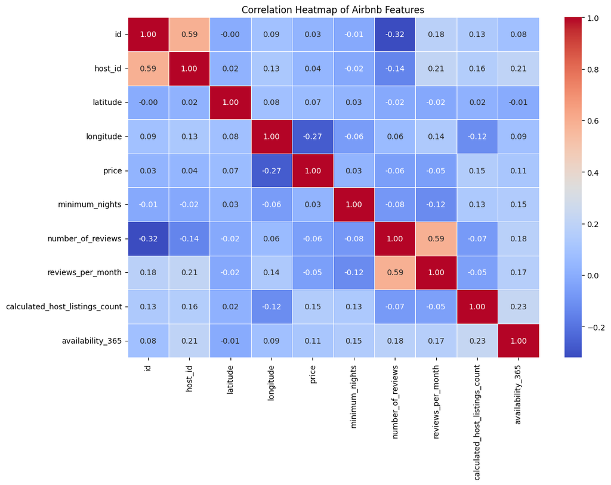

```python
correlation_matrix = df.corr(numeric_only=True)

# Create a heatmap
plt.figure(figsize=(12, 8))
sns.heatmap(correlation_matrix, annot=True, cmap="coolwarm", fmt=".2f", linewidths=0.5)

# Add labels and title
plt.title("Correlation Heatmap of Airbnb Features")
plt.show()
```

**1. Price vs. Availability**

- **Low correlation** between `price` and `availability_365`.
- This suggests **pricing does not strongly influence how often a listing is available**.

**2. Price vs. Number of Reviews**

- **Negative correlation** between `price` and `number_of_reviews`/`reviews_per_month`.
- This implies **cheaper listings tend to receive more reviews**, possibly due to higher affordability and demand.

**3. Reviews per Month vs. Availability** **Some positive correlation** between `reviews_per_month` and `availability_365`.

- Listings that are **more available tend to get more reviews**, indicating they are booked frequently.

Overall no strong correlations between the variables

## Geospatial Analysis

```python
# median price per neighborhood
neighborhood_price = df.groupby("neighbourhood")["price"].median().reset_index()
neighborhood_price = neighborhood_price.sort_values(by="price", ascending=False)

# reviews per month as a proxy for demand
neighborhood_demand = df.groupby("neighbourhood")["reviews_per_month"].mean().reset_index()
neighborhood_demand = neighborhood_demand.sort_values(by="reviews_per_month", ascending=False)

# Merge price and demand data
neighborhood_data = pd.merge(neighborhood_price, neighborhood_demand, on="neighbourhood")

# Display DataFrame as a formatted string
neighborhood_data.to_string(index=False)


display(neighborhood_data)
```

|  | neighbourhood | price | reviews_per_month |
| --- | --- | --- | --- |
| 0 | Woodrow | 700.0 | 0.000000 |
| 1 | Tribeca | 275.5 | 0.566218 |
| 2 | Neponsit | 274.0 | 1.600000 |
| 3 | NoHo | 250.0 | 0.624286 |
| 4 | Willowbrook | 249.0 | 0.800000 |
| ... | ... | ... | ... |
| 215 | Tremont | 41.5 | 1.084000 |
| 216 | New Dorp Beach | 40.0 | 2.200000 |
| 217 | Hunts Point | 40.0 | 1.121667 |
| 218 | Castle Hill | 39.0 | 0.616667 |
| 219 | Concord | 35.0 | 1.452000 |

220 rows × 3 columns

Calculating Key Metrics Median price per neighborhood was calculated to identify high-priced areas. Average reviews per month per neighborhood were used as a proxy for demand (higher reviews → more bookings)

### Understanding the Spatial Distribution of Prices

To identify high-value investment areas, we created a **heatmap** representing the spatial distribution of Airbnb prices across NYC. The **warmer (red) areas** indicate **higher-priced** listings, while **cooler (blue) areas** correspond to **lower-priced** listings.

**Key Observations from the Price Heatmap:**

- **Manhattan** exhibits the **highest concentration** of expensive listings, particularly in **Midtown, Tribeca, and SoHo**.
- **Brooklyn and Queens** have a **mix of mid-range and budget listings**, with prices dropping significantly as we move away from the city center.
- Areas in **Staten Island and the Bronx** have **significantly lower prices**, making them **less attractive** for premium Airbnb investments.

```python
nyc_map = folium.Map(location=[40.7128, -74.0060], zoom_start=11)


# Create a heatmap layer
heat_data = list(zip(df["latitude"], df["longitude"], df["price"]))
HeatMap(heat_data, radius=12, blur=8, max_zoom=1).add_to(nyc_map)

# Display the interactive map
nyc_map
```

Make this Notebook Trusted to load map: File -> Trust Notebook

[interactive chart not shown]

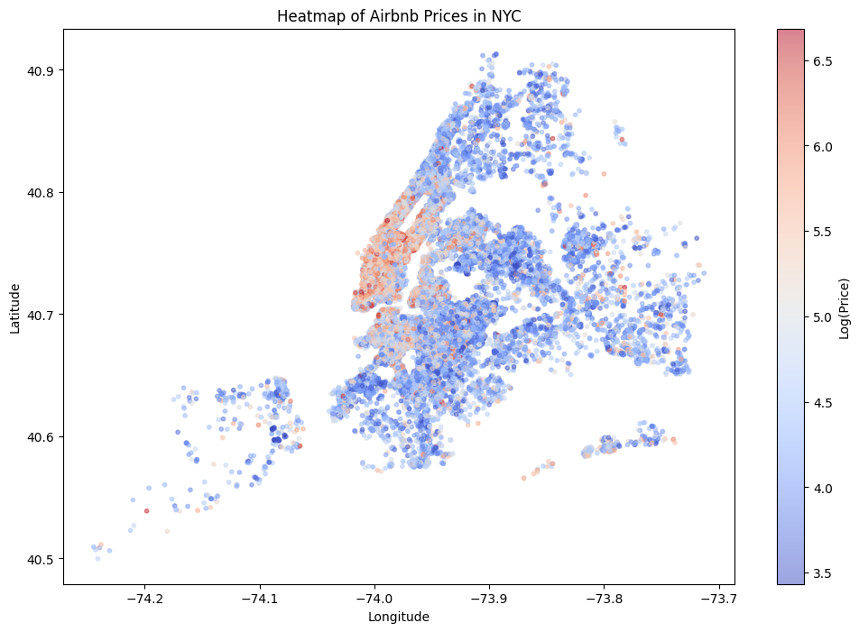

```python
plt.figure(figsize=(12, 8))
plt.scatter(df["longitude"], df["latitude"],
            c=np.log1p(df["price"]), cmap="coolwarm", alpha=0.5, s=10)

# Add labels and title
plt.colorbar(label="Log(Price)")
plt.xlabel("Longitude")
plt.ylabel("Latitude")
plt.title("Heatmap of Airbnb Prices in NYC")

# Show plot
plt.show()
```